# Redoing UK and US with their final data sets

## Moshe, Sep 7, 2017

## Dataset 'UK_US'

Scott's spreadsheet "UK_US_Series_ALL.xlsx" contains GDP data for UK and US from [MeasuringWorth.com](https://measuringworth.com/ukgdp/result.php), all in 2010 USD. The UK 'consistent series' is from 1700 to the present, consistent in terms of the geographical area it is measuring. That is, it is for England, Wales, Scotland and Northern Ireland. Prior to 1801 Northern Ireland is assumed to be a constant share of UK GDP given a lack of available data.

Here are UK_US dataset modeling and UK_US dataset plots. The results are exactly the same as from the previous data, except of course that the UK is now properly in 2010 USD.

UK from 1801: From its description, the truly clean part of the UK consistent series is only from 1801. Taking that as the UK data yields very successful modeling---the average deviation of model from data is only 9.31%, the largest deviation is 32.13%, in 1932 (Great Depression). Since 216 data points is plenty enough, this will be our standard UK dataset.

### GDP per Capita (GDPPC)

The spreadsheet provides also these data. Plots of GDPPC data, especially using log scale for GDPCC, show a quantity that rises exponentially. So we can try modeling it with hindered growth.

GDP per Capita modeling is reasonably successful. Both US and UK show unhindered exponential growth with constant annual growth rates of 1.71% and 1.14%, respectively.

### Populations

Modeling Populations produces one of our best successes. All 227 points of the US population model are within 3% of the data, on average, the largest deviation is only 7.85% in 1885. What's more, the results are in perfect agreement with the UN population model that started only in 1950--the model predictions for 2050 are 408 vs 414 million. Both models state that currently the US population grows in the hindered mode, adding $r_uQ_h$ = 3.6 million (2.7 million for the UN dataset) per year. But the UN model could only tell us that hindering started long before 1950; it could not capture properly the individual parameters $r_u$ and $Q_h$ and gave them unreasonable values, such as $r_u$ = 11.69%. With the new extended dataset we now have $r_u$ = 3.2% and know that the hindering threshold $Q_h$ = 112 million was crossed in 1923.

Hindered-growth modeling fails for the UK population so I tried Linear model for the UK Population. This works well --- the average deviation of model from data is 3.63%, the largest deviation is 7.88% in 1914; from 1801 to 2016, population variation of the UK is well described as adding 256 thousand people every year.

### Summary

The success of US population modeling, producing similar results from both large and limited datasets, in encouraging. In contrast, US GDP modeling with the limited dataset for 1967--2015 produced significant differences from the larger dataset. Presumably, the smooth population data yield more reliable model results than the noisy GDP data, which is not surprising.

Looking at the data alone, the Growth Factors show that GDP increases because both population and GDP/Capita are increasing. In the UK case, the GDPPC contribution to the growth was more than twice that of population.

Our models are internally self-consistent. GDPPC grows exponentially at a constant $r_u$ for both nations. Combined with linear population growth, the UK GDP grows unhindered, puerly exponentially. In the US, hindering of the population growth yields hindering of GDP. The primary quantities are, of course, population and GDP --- GDPPC is a derived quantity. Would be good if we could get directly the population data instead of deriving them in a roundabout way.

### Erratum

The last statement is wrong---it is impossible to get a self-consistent set of individual models for all three quantities. Denote GDP by $G$, population by $P$ and GDPPC by $C$, then $C = G/P$. Because the growth rate of quantity $Q$ is $r = d\ln Q/dt$,

$$ r_C = r_G - r_P = \frac{r_{G,u}}{1 + G/G_h} - \frac{r_{P,u}}{1 + P/P_h} \qquad \qquad (1) $$

where the last equality uses the 1st-order hindering parametrization of the growth rates for $G$ and $P$. Evidently, $r_C$ can have the same form if and only if the denominators of the two terms on the right are identical:

$$ 1 + G/G_h = 1 + P/P_h \qquad \Rightarrow \qquad C = \frac{G}{P} = \frac{G_h}{P_h} $$

That is, $C$ is constant, $G$ is proportional to $P$. Since GDPPC is **not** constant, modeling it with the hindered growth parametrization is internally inconsistent. Such modeling was numerically possible only because of the noisy data, producing models with model-from-data average deviations of 16% and 24% for US and UK, respectively, and maximum deviations of 52% for the US and 47% for the UK.

While reasonably acceptable numerically, the only self-consistent modeling of GDPPC is to mimic what's done with the data and take the ratio of models for GDP and POP, as done below. This produces somewhat better fits, with deviations of model from data of 12% and 10% for US and UK, respectively, and largest deviations of 37% and 35%. An interesting result, seen in the plots of GDP:POP model ratios, is that the growth rates of GDPPC show an **increase** with time, in nice agreement with the underlying 20-years rolling average of the data. Clearly, such an effect can never be captured by the hindering parametrization. In the US case, the growth rate of GDPPC rises continuously at a more or less constant rate, peaking at 2.3%/yr in 1945, slowly declining afterwards. In the case of the UK there's an initial rapid increase, followed by a more moderate rise with no clear sign of decrease, reaching a maximum of 1.7% in 2049. The difference in the behavior of GDPPC on one hand and of GDP and POP on the other is evident from the plot of UK:US ratio for all three quantities, both data and models.

```python
import numpy as np
from numpy import exp, sqrt, log as ln, log10 as log
import matplotlib.pyplot as plt
import sys
sys.path.append('../Tools')
from ME_utils import *
from econ import *
from GDP import *
from POP import *
```

Back to Top

# UK_US dataset --- Modeling

```python
data_set = UK_US
args = analyze(data_set)
Nations, success, Year, GDP, ru, Qh, future, GDP_model, r_model = summary_print(*args)
```

```
UK: 317 data points
GDP has grown from 1.52E+10($10) in 1700 to 2.73E+12($10) in 2016
an increase by factor of 1.8e+02

*** 2-parameter fit [ru, qh]:
 Initial guess --- None
 Final result  --- [1.603E+00, 1.292E+10]
*** Best-fit parameters:
   ru = 1.60%      unhindered (unsaturated) growth rate
   Qh = 1.96E+20   Hindering (saturation) GDP in 2010USD
   qh = Qh/Q0 = 1.29E+10
  Relative errors of fitting parameters:
   err(ru) = 2.25E-03
   err(Qh) = 5.85E-32
***Data covers a range of 5.07 growth times
***Hindering paramater H = 2.668E-09
   Hindering degree Qf/Qh = 1.39E-08
***Average deviation of model from data is 34.47%
   largest deviation of model from data is 57.58% in 1819

***Model predictions for 2050 for UK economy:
   GDP of 4.15E+12 $10 and annual growth rate 1.60%

______________________________________________________________________

US: 227 data points
GDP has grown from 4.40E+09($10) in 1790 to 1.69E+13($10) in 2016
an increase by factor of 3.8e+03

*** 2-parameter fit [ru, qh]:
 Initial guess --- None
 Final result  --- [4.001E+00, 5.372E+03]
*** Best-fit parameters:
   ru = 4.00%      unhindered (unsaturated) growth rate
   Qh = 2.37E+13   Hindering (saturation) GDP in 2010USD
   qh = Qh/Q0 = 5.37E+03
  Relative errors of fitting parameters:
   err(ru) = 1.93E-03
   err(Qh) = 3.10E-02
***Data covers a range of 9.04 growth times
```

[output cut: 15 more lines]

```
H = (R - 1)/(qs*ln R)  Hindrance parameter

nation                 entries     R     r_u(%)     qs     Qf/Qh       H
____________________________________________________________________________
UK                      317        180    1.60  1.29e+10  1.39e-08  2.67e-09
US                      227   3.83e+03    4.00  5.37e+03     0.713    0.0864


Sorted by H:
nation                 entries     R     r_u(%)     qs     Qf/Qh       H
____________________________________________________________________________
UK                      317        180    1.60  1.29e+10  1.39e-08  2.67e-09
US                      227   3.83e+03    4.00  5.37e+03     0.713    0.0864

All data fitted successfully
```

Back to Top

# UK_US dataset --- Plotting

```
Plotting results for UK
```

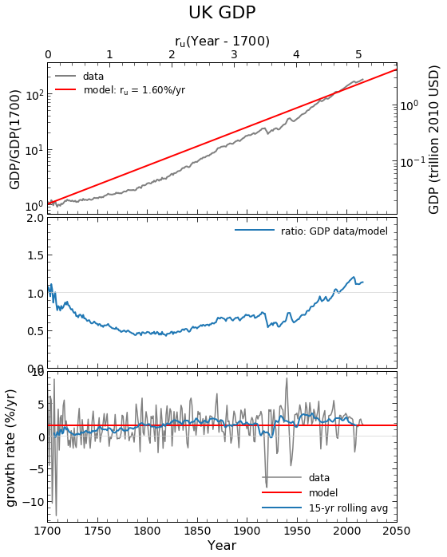

```
Plotting results for US
```

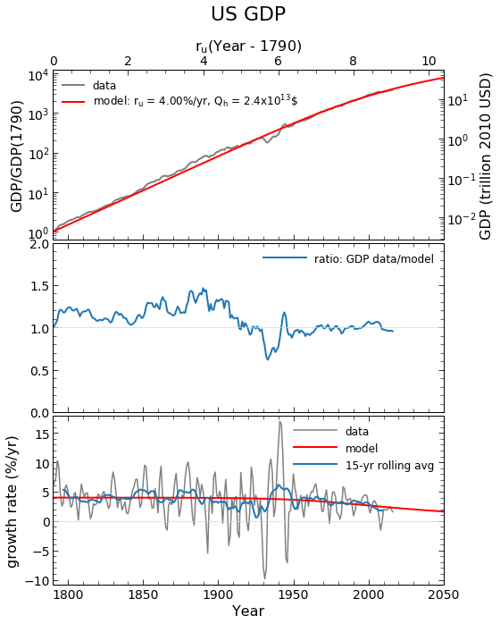

```python
dn = 15; loc_top = 'upper left'; loc_bot = 'upper right'
for nation in Nations:
    print 'Plotting results for',nation
    gr, avg = gr_data(GDP[nation], Year[nation])
    loc_bot_ = 'lower right' if nation=='UK' else loc_bot
    basic_plot(nation, Year[nation], GDP[nation], gr, avg,
           r_u=ru[nation], Qh=Qh[nation], Q0='',
           loc_top=loc_top, loc_bot=loc_bot_,
           future=future[nation], top_axis=True, dn=dn,
           model_r=r_model[nation], model_Q=GDP_model[nation])
    plt.show()
```

Back to Top

# UK from 1801

```
UK: 216 data points
GDP has grown from 3.63E+10($10) in 1801 to 2.73E+12($10) in 2016
an increase by factor of 75

*** 2-parameter fit [ru, qh]:
 Initial guess --- None
 Final result  --- [2.003E+00, 4.283E+09]
*** Best-fit parameters:
   ru = 2.00%      unhindered (unsaturated) growth rate
   Qh = 1.55E+20   Hindering (saturation) GDP in 2010USD
   qh = Qh/Q0 = 4.28E+09
  Relative errors of fitting parameters:
   err(ru) = 1.59E-03
   err(Qh) = 9.64E-32
***Data covers a range of 4.31 growth times
***Hindering paramater H = 4.012E-09
   Hindering degree Qf/Qh = 1.76E-08
***Average deviation of model from data is 9.31%
   largest deviation of model from data is 32.13% in 1932

***Model predictions for 2050 for UK economy:
   GDP of 5.32E+12 $10 and annual growth rate 2.00%

______________________________________________________________________
```

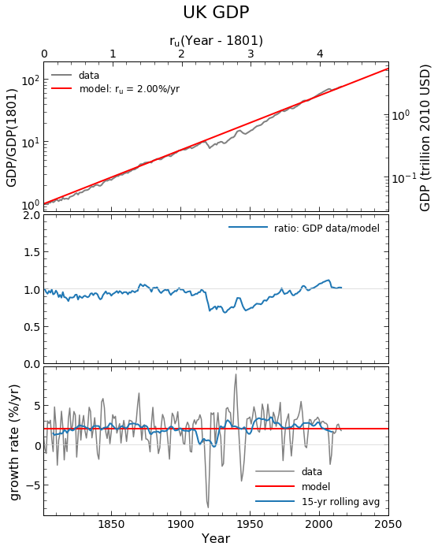

```python
nation = 'UK'
i = np.searchsorted(Year['UK'], 1801)
yr = Year['UK'][i:]
Q = GDP['UK'][i:]
ru, Qh, Q0_dummy, future, Q_model, r_model = fitting(nation, Q, yr)
gr, avg = gr_data(Q, yr)
basic_plot(nation, yr, Q, gr, avg, r_u=ru, Qh=Qh,
           loc_top=loc_top, loc_bot='lower right',
           future=future, top_axis=True, dn=dn,
           model_r=r_model, model_Q=Q_model)
#plt.savefig('UK1801.pdf')
plt.show()
```

Back to Top

```python
data_dir = '../Data/'
fname = 'UK_US_Series_ALL.xlsx'
wb = openpyxl.load_workbook(data_dir+fname)
sheet = wb.get_sheet_by_name('Sheet1')
def entry(row, col): return sheet.cell(row=row, column=col).value
```

```python
#GDPPC 2010 USDPC
#        US     UK
#rows 93-319   105-319
#cols    G       I
years_col = 1
names_row = 2
Nations = ['US', 'UK']
rows = [range(93,320), range(104,320)]
cols = [7, 9]
```

```python
Year, GDPPC = {},{}
for n, nation in enumerate(Nations):
    print entry(names_row, cols[n])
    Year[nation] = np.array([entry(r, years_col) for r in rows[n]])
    GDPPC[nation] = np.array([entry(r, cols[n]) for r in rows[n]])
    #print Year[nation]
    #print GDPPC[nation]
```

```
US (2010 USD)
UK (Consistent Series--in 2010 USD)
```

```python
G, G_model, POP = {}, {}, {}
G['UK'] = Q
G['US'] = GDP['US']
G_model['UK'] = Q_model
G_model['US'] = GDP_model['US']
for nation in Nations:
    POP[nation] = G[nation]/GDPPC[nation]
```

Back to Top

# GDP per Capita -- Data

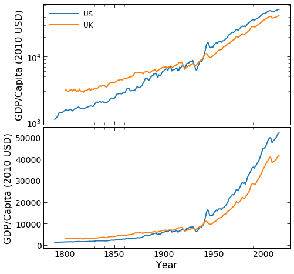

```python
Fig, (top, bot) = plt.subplots(2,1, sharex=True, figsize=(8, 7))
for fig in [top, bot]:
    fig.xaxis.set_minor_locator(AutoMinorLocator())
    if fig is top: plt.setp(fig.get_xticklabels(), visible=False)
    fig.set_ylabel('GDP/Capita (2010 USD)')
    for nation in Nations:
        fig.plot(Year[nation], GDPPC[nation], label=nation)
#bot.get_yaxis().set_major_formatter(FormatStrFormatter("%.0E"))
bot.set_xlabel('Year')
top.set_yscale('log')
top.legend()
Fig.subplots_adjust(left=0.2,right=0.93, top=.95, hspace=0.02)
#plt.savefig('UK_US_GDPPC.pdf')
plt.show()
```

Back to Top

# GDP per Capita -- Modeling

```python
R, ru, qs, Qh, H, success, failure, future, GDPPC_model, r_model\
       = fit_it(Nations, Year, GDPPC, gdppc=True)
```

```
US: 227 data points
GDP per capita has grown from 1.12E+03($10) in 1790 to 5.21E+04($10) in 2016
an increase by factor of 47

*** 2-parameter fit [ru, qh]:
 Initial guess --- None
 Final result  --- [1.710E+00, 3.488E+09]
*** Best-fit parameters:
   ru = 1.71%      unhindered (unsaturated) growth rate
   Qh = 3.91E+12   Hindering (saturation) GDP per capita in 2010USD
   qh = Qh/Q0 = 3.49E+09
  Relative errors of fitting parameters:
   err(ru) = 2.10E-03
   err(Qh) = 1.28E-30
***Data covers a range of 3.86 growth times
***Hindering paramater H = 3.399E-09
   Hindering degree Qf/Qh = 1.33E-08
***Average deviation of model from data is 15.86%
   largest deviation of model from data is 51.52% in 1933

***Model predictions for 2050 for US economy:
   GDP per capita of 9.56E+04 $10 and annual growth rate 1.71%

______________________________________________________________________

UK: 216 data points
GDP per capita has grown from 3.11E+03($10) in 1801 to 4.16E+04($10) in 2016
an increase by factor of 13

*** 2-parameter fit [ru, qh]:
 Initial guess --- None
 Final result  --- [1.136E+00, 2.495E+08]
*** Best-fit parameters:
   ru = 1.14%      unhindered (unsaturated) growth rate
   Qh = 7.75E+11   Hindering (saturation) GDP per capita in 2010USD
   qh = Qh/Q0 = 2.49E+08
  Relative errors of fitting parameters:
   err(ru) = 7.58E-03
   err(Qh) = 2.23E-27
***Data covers a range of 2.44 growth times
***Hindering paramater H = 1.916E-08
   Hindering degree Qf/Qh = 5.37E-08
***Average deviation of model from data is 23.75%
   largest deviation of model from data is 47.15% in 1921

***Model predictions for 2050 for UK economy:
   GDP per capita of 5.25E+04 $10 and annual growth rate 1.14%

______________________________________________________________________
```

```
Plotting results for US
```

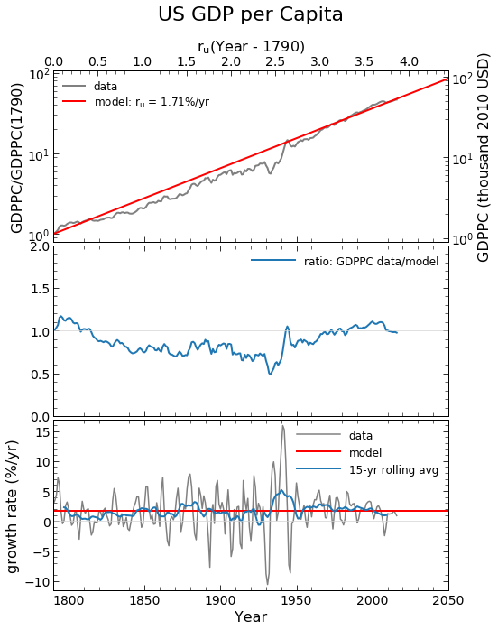

```
Plotting results for UK
```

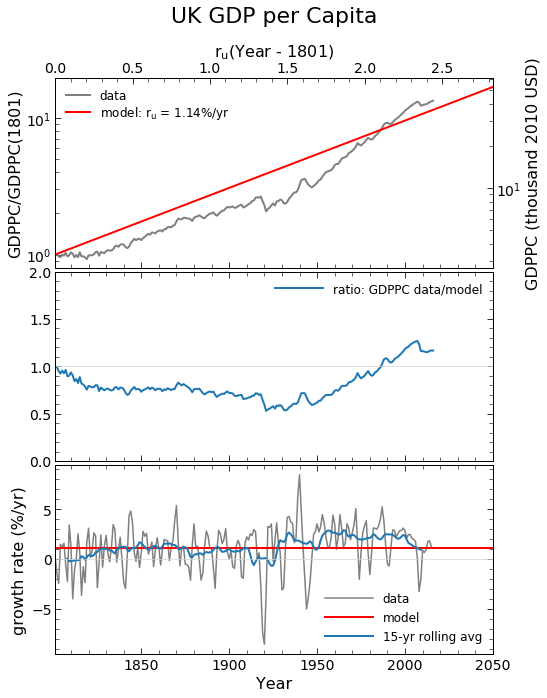

```python
for nation in Nations:
     print 'Plotting results for',nation
     gr, avg = gr_data(GDPPC[nation], Year[nation])
     loc_bot_ = 'lower right' if nation=='UK' else loc_bot
     basic_plot(nation, Year[nation], GDPPC[nation], gr, avg,
           r_u=ru[nation], Qh=Qh[nation], Q0='',
           loc_top=loc_top, loc_bot=loc_bot_,
           future=future[nation], top_axis=True, dn=dn,
           model_r=r_model[nation], model_Q=GDPPC_model[nation], gdppc=True)
     plt.show()
```

Back to Top

# Populations vs UN data

```python
Year_UN = np.arange(1950, 2016)
data_row = [177, 262]  # UK, US
Nations_UN, POP_UN = POP_excel(data_row)
err ={}
print '***Comparing populations from GDP per Capita with UN data\n'
for n, nation in enumerate(['UK', 'US']):
    print '%s population from GDPPC vs UN data for %s' %(nation, Nations_UN[n])
    i1 = np.searchsorted(Year[nation], Year_UN[0])
    i2 = np.searchsorted(Year[nation], Year_UN[-1]) +1
    err[nation] = POP_UN[Nations_UN[n]]/POP[nation][i1:i2] - 1

print '\nRelative deviations:'
print 'Year',
for nation in Nations: print '%12s' %nation,
for yr, year in enumerate(Year_UN):
    print
    print year,
    for nation in Nations:
        print '%14.2E' %err[nation][yr],
```

```
***Comparing populations from GDP per Capita with UN data

UK population from GDPPC vs UN data for United Kingdom
US population from GDPPC vs UN data for United States of America

Relative deviations:
Year           US           UK
1950       4.69E-02       8.57E-04
1951       4.29E-02       6.31E-03
1952       4.06E-02       4.77E-03
1953       4.03E-02       4.00E-03
1954       3.96E-02       3.53E-03
1955       3.94E-02       3.47E-03
1956       3.91E-02       2.88E-03
1957       3.84E-02       2.49E-03
```

[output cut: 58 more lines]

Back to Top

# Modeling Populations

```
US: 227 data points
Population has grown from 3.93E+06 in 1790 to 3.23E+08 in 2016
an increase by factor of 82

*** 2-parameter fit [ru, qh]:
 Initial guess --- None
 Final result  --- [3.200E+00, 2.846E+01]
*** Best-fit parameters:
   ru = 3.20%      unhindered (unsaturated) growth rate
   Qh = 1.12E+08   Hindering (saturation) population
   qh = Qh/Q0 = 2.85E+01
  Relative errors of fitting parameters:
   err(ru) = 4.88E-03
   err(Qh) = 1.48E-02
***Data covers a range of 7.23 growth times
***Hindering paramater H = 6.478E-01
   Hindering degree Qf/Qh = 2.89
   Hindering threshold (Q > Qh) crossed in 1923
   Hindered growth mode has a rate of 3.58E+06 per year
***Average deviation of model from data is 3.08%
   largest deviation of model from data is 7.85% in 1885

***Model predictions for 2050 for US population:
   Population of 4.14E+08 and annual growth rate 0.68%

______________________________________________________________________
```

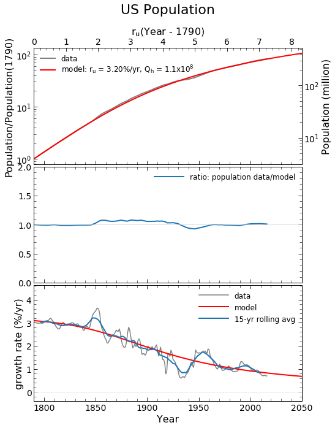

```
UK: 216 data points
Population has grown from 1.17E+07 in 1801 to 6.56E+07 in 2016
an increase by factor of 5.6

*** 2-parameter fit [ru, qh]:
 Initial guess --- None
Optimal parameters not found: The maximum number of function evaluations is exceeded.
Failed to fit the data for UK

______________________________________________________________________
```

```python
qs, ru, Qh, future, POP_model, r_model = {}, {}, {}, {}, {}, {}
H, R = {}, {}
for nation in Nations:
    try:
        ru[nation], Qh[nation], Q0_dummy, future[nation], POP_model[nation], r_model[nation]\
               = fitting(nation, POP[nation], Year[nation], gdp=False)
        gr, avg = gr_data(POP[nation], Year[nation])
        loc_bot_ = 'lower right' if nation=='UK' else loc_bot
        basic_plot(nation, Year[nation], POP[nation], gr, avg,
           r_u=ru[nation], Qh=Qh[nation], Q0='', POP=True,
           loc_top=loc_top, loc_bot=loc_bot_,
           future=future[nation], top_axis=True, dn=dn,
           model_r=r_model[nation], model_Q=POP_model[nation])
        plt.show()
    except:
        pass
```

Back to Top

# UK Population -- Linear model

```
UK: 216 data points
Population has grown from 1.17E+07 in 1801 to 6.56E+07 in 2016
an increase by factor of 5.6

*** Fitting with linear model:   Q = Q0*(1 + r0*t)
 Initial guess --- None
 Final result  --- [9.375E-01, 2.190E-02]
*** Best-fit parameters:
   r0 = 2.34 %/year    Q0 = 1.10E+07
   Population increasses by 2.56E+05 per year
  Relative errors of fitting parameters:
   err(r0) = 1.95E-02   err(G0)= 6.73E-03
***Average deviation of model from data is 3.63%
   largest deviation of model from data is 7.88% in 1914

***Model predictions for 2050 for UK population:
   Population of 7.47E+07 and annual growth rate 0.34%

______________________________________________________________________
```

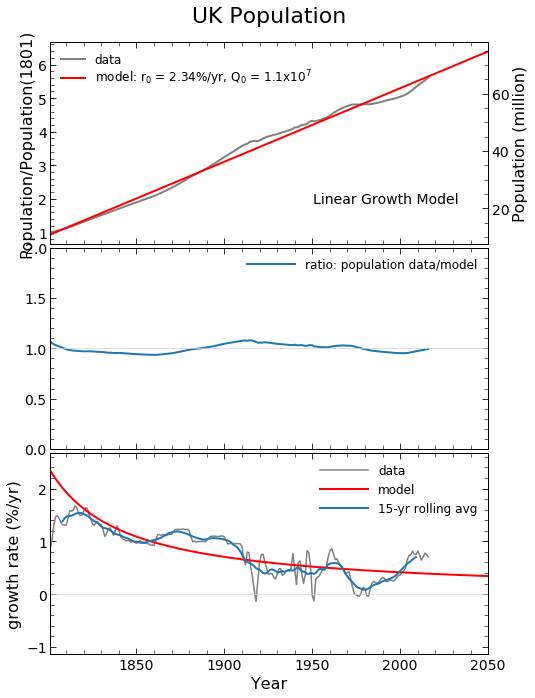

```python
nation = 'UK'
r_u, Qh, Q0, future_, POP_model[nation], r_model\
       = fitting(nation, POP[nation], Year[nation], gdp=False, mode='lin')
gr, avg = gr_data(POP[nation], Year[nation])
#loc_bot_ = 'lower right' if nation=='UK' else loc_bot
basic_plot(nation, Year[nation], POP[nation], gr, avg,
           r_u=r_u, Qh=Qh, Q0='', POP=True, linear=True,
           loc_top=loc_top, loc_bot=loc_bot_,
           future=future_, dn=dn,
           model_r=r_model, model_Q=POP_model[nation])
plt.show()
```

Back to Top

# Growth Factors

```python
V_list = [G, POP, GDPPC]
V_is = ['GDP(USD 2010)', 'Population', 'GDP/Capita']
for nation in Nations:
    yr1 = Year[nation][0]; yr2 = Year[nation][-1]
    print '\n***%s:\n   Change from %i to %i for the following quantities' %(nation, yr1, yr2)
    for v, V in enumerate(V_list):
        print 3*' '+V_is[v].ljust(20),
        print  'from %8.3G to %8.3G, by factor %8.3G' %(V[nation][0], V[nation][-1], V[nation][-1]/V[nation][0])
```

```
***US:
   Change from 1790 to 2016 for the following quantities
   GDP(USD 2010)        from  4.4E+09 to 1.69E+13, by factor 3.83E+03
   Population           from 3.93E+06 to 3.23E+08, by factor     82.3
   GDP/Capita           from 1.12E+03 to 5.21E+04, by factor     46.5

***UK:
   Change from 1801 to 2016 for the following quantities
   GDP(USD 2010)        from 3.63E+10 to 2.73E+12, by factor     75.2
   Population           from 1.17E+07 to 6.56E+07, by factor     5.61
   GDP/Capita           from 3.11E+03 to 4.16E+04, by factor     13.4
```

Back to Top

# GDPPC model from GDP:POP model ratio

```python
#Get the model for GDPPC from model[GDP]/model[POP]:

print '\n***Modeling GDP per Capita from the ratio of models for GDP and Population'
PC_model, PC_rmodel = {}, {}
for nation in Nations:
    print '\n', nation, ':'
    PC_model[nation] = G_model[nation]/POP_model[nation]
    #Calculate the growth rate of the GDPPC/POP model:
    future_ = np.arange(Year[nation][0], 2051 )
    PC_rmodel[nation], _ = gr_data(PC_model[nation], future_ )
    #and the modeling errors
    yf = np.searchsorted(future_, Year[nation][-1]) + 1
    err = 100*abs(GDPPC[nation]/PC_model[nation][:yf] - 1)

    print '***Average deviation of model from data is %4.2f'\
                %(np.average(err))+'%'
    print '   largest deviation of model from data is %4.2f'\
                %(np.amax(err))+'%' + ' in %i'%Year[nation][np.argmax(err)]
    print '***Growth rate reaches a peak of %4.2f'\
                %(np.amax(PC_rmodel[nation]))+'%/yr' + ' in %i'%future_[np.argmax(PC_rmodel[nation])]
```

```
***Modeling GDP per Capita from the ratio of models for GDP and Population

US :
***Average deviation of model from data is 11.85%
   largest deviation of model from data is 37.54% in 1933
***Growth rate reaches a peak of 2.33%/yr in 1945

UK :
***Average deviation of model from data is 10.31%
   largest deviation of model from data is 34.85% in 1932
***Growth rate reaches a peak of 1.66%/yr in 2049
```

Back to Top

# Plots of GDPPC data and GDP:POP model ratio

```
Plotting results for US
```

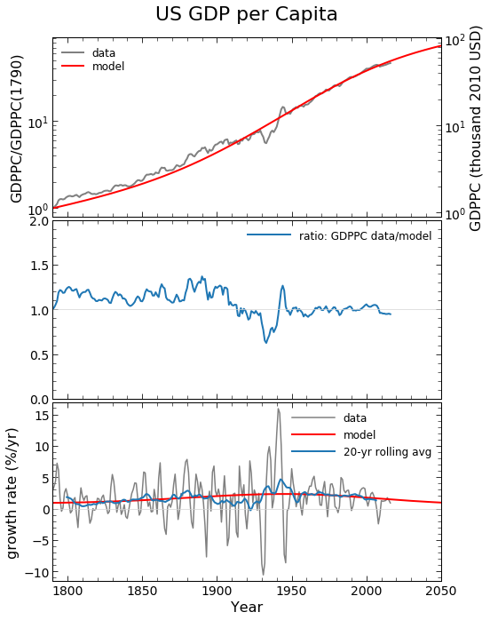

```
Plotting results for UK
```

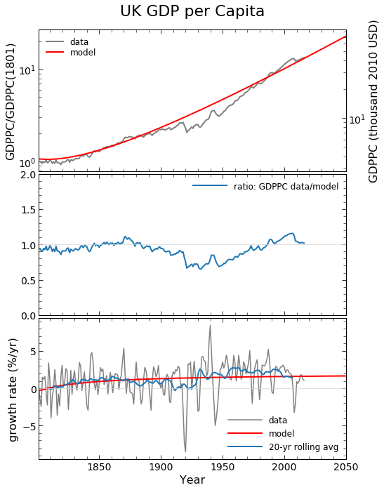

```python
#and plot the models with the data
for nation in Nations:
     print 'Plotting results for',nation
     gr, avg = gr_data(GDPPC[nation], Year[nation])
     future_ = np.arange(Year[nation][0], 2051 )
     loc_bot_ = 'lower right' if nation=='UK' else loc_bot
     basic_plot(nation, Year[nation], GDPPC[nation], gr, avg,
           model_r=PC_rmodel[nation], model_Q=PC_model[nation],
           loc_top=loc_top, loc_bot=loc_bot_,
           future=future_, dn=20, gdppc=True)
     plt.show()
```

Back to Top

# UK:US ratio for all quantities

```python
#Calcuate UK:US ratios for data and models
y1 = np.searchsorted(Year['US'], 1801)
M_list = [G_model, POP_model, PC_model]

R_data, R_model = [], []
[R_data.append(V['UK']/V['US'][y1:]) for V in V_list ]
[R_model.append(M['UK']/M['US'][y1:]) for M in M_list ]
```

```
[None, None, None]
```

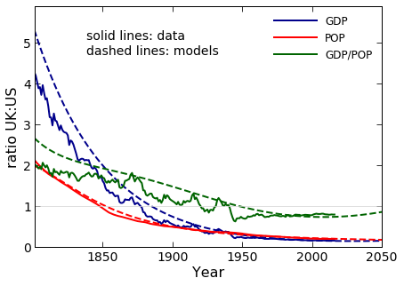

```python
#and plot them:
future = np.arange(1801,2051)
x_range = (future[0], future[-1])
lbls = ['GDP', 'POP', 'GDP/POP']
Fig, fig = plt.subplots(figsize=(7,5))
for r in range(len(V_list)):
    fig.plot(Year['UK'], R_data[r], color=color[r], label=lbls[r] )
    fig.plot(future, R_model[r],'--', color=color[r] )
#plot baseline at ratio 1
fig.plot(x_range, (1,1), color='lightgray', lw=0.7)
fig.set_xlim(x_range)
fig.set_ylim(0,5.9)
fig.set_xlabel('Year')
fig.set_ylabel('ratio UK:US')
fig.legend()
txt = 'solid lines: data \ndashed lines: models'
fig.text(0.15,0.8,txt,transform=fig.transAxes)

plt.show()
```

Back to Top